# Harry Potter Episodes 5 and 6 - Wizard’s chess - Predict who wins in chess

This tutorial is adapted from Brian Li’s chess modelling tutorial.

## Loading packages

```r
library(tidyverse) # for data summarising and wrangling
library(nnet) # for running multinomial logistic regression
library(MASS) # for stepAIC feature selection
library(rpart) # for decision trees
library(rpart.plot) # for decision trees
library(caret) # for confusion matrix
library(gbm) # for gbm
```

## Load dataset

```r
wizards_chess = read.csv("wizards_chess_reduced.csv")
head(wizards_chess)
```

|  | eco | white_elo | black_elo | result | elo_difference | eco_cat | white_player | black_player |
| --- | --- | --- | --- | --- | --- | --- | --- | --- |
| 1 | A40 | 2764 | 2470 | 1-0 | 294 | A40 - A44 | Ron Weasley | Harry Potter |
| 2 | C45 | 2512 | 2740 | 1/2-1/2 | -228 | C20 - C99 | Hermione Granger | Kylie Nowak |
| 3 | D31 | 2556 | 2737 | 0-1 | -181 | D00 - D69 | Evangelina Cope | Charlotte Dillon |
| 4 | B92 | 2567 | 2720 | 1/2-1/2 | -153 | B20 - B99 | Floyd Tinker | Benjamin Christensen |
| 5 | E73 | 2567 | 2714 | 0-1 | -147 | E60 - E99 | Herman Nall | Shelli Lock |
| 6 | A05 | 2707 | 2584 | 1-0 | 123 | A00 - A39 | Bridgette Handy | Jung Blank |

```r
# checking number of grandmasters
length(which(wizards_chess$white_elo >=2500))/length(wizards_chess$white_elo) * 100
```

```
## [1] 68.5541
```

```r
length(which(wizards_chess$black_elo >=2500))/length(wizards_chess$black_elo) * 100
```

```
## [1] 68.91159
```

##### Explanation of dataset

- `eco` - ECO codes is a classification system for chess opening moves. Chess openings can be divided into five volumes from “A” through “E”.
- `white_elo` - The Elo rating system is a technique to calculate the relative skill levels of players compared to other players. Most chess Grandmasters have an Elo rating of 2500 and above. 68% of players are at the Grandmaster level.
- `result` - This indicates whether the winner is ‘white’, ‘black’ or ‘draw’. 1-0 = white winner, 1/2-1/2 = draw, 0-1 = black winner.
- `elo_difference` - This tells us the difference in Elo between the two players which is an indication of the difference in skill level.
- `eco_cat` - ECO is categorised into different groups.

## Data preprocessing

Since chess Elos are not linear (i.e., the difference between 2700 and 2800 is greater than the difference between 1900 and 2000), we will calculate the z-score of each player and raise ‘e’ to that z-score.

Z-score provides how many standard deviations away a value is from the mean.

## Creating adjusted elo variable

```r
# Create a dataframe containing all the Elo ratings to get the mean and standard deviation
tmp <- data.frame(wizards_chess$white_elo, wizards_chess$black_elo)
tmp <- stack(tmp)
mean_elo = mean(tmp[,1])
sd_elo = sd(tmp[,1])

# Calculating z-scores and raise 'e' to the z-scores
wizards_chess$adjusted_white_elo <- exp(pnorm(wizards_chess$white_elo, mean_elo, sd_elo))
wizards_chess$adjusted_black_elo <- exp(pnorm(wizards_chess$black_elo, mean_elo, sd_elo))
wizards_chess$adjusted_elo_difference <- wizards_chess$adjusted_white_elo - wizards_chess$adjusted_black_elo
```

## Creating winner variable

```r
# Set win to 1-0, lose to 0-1
win = " 1-0"
lose = " 0-1"

# Generate a new variable called winner that assigns 1-0 to white wins, 0-1 to black wins, and 1/2-1/2 to a draw
wizards_chess <- mutate(wizards_chess, winner = ifelse(result==win,"white",ifelse(result==lose,"black","draw")))

# Make the column a factor
wizards_chess$winner = as.factor(wizards_chess$winner)

table(wizards_chess$winner, wizards_chess$result)
```

```
##
##            *  0-1  1-0  1/2-1/2
##   black    0 3129    0        0
##   draw     2    0    0     7950
##   white    0    0 4584        0
```

## Explore the data

Let’s explore the percentages of white wins, black wins and draws.

```r
table(wizards_chess$winner)
```

```
##
## black  draw white
##  3129  7952  4584
```

```r
# white wins %
length(which(wizards_chess$winner == "white"))/length(wizards_chess$winner)
```

```
## [1] 0.2926269
```

```r
# black wins %
length(which(wizards_chess$winner == "black"))/length(wizards_chess$winner)
```

```
## [1] 0.1997447
```

```r
# draws %
length(which(wizards_chess$winner == "draw"))/length(wizards_chess$winner)
```

```
## [1] 0.5076285
```

## Checking the distribution of the elo differences.

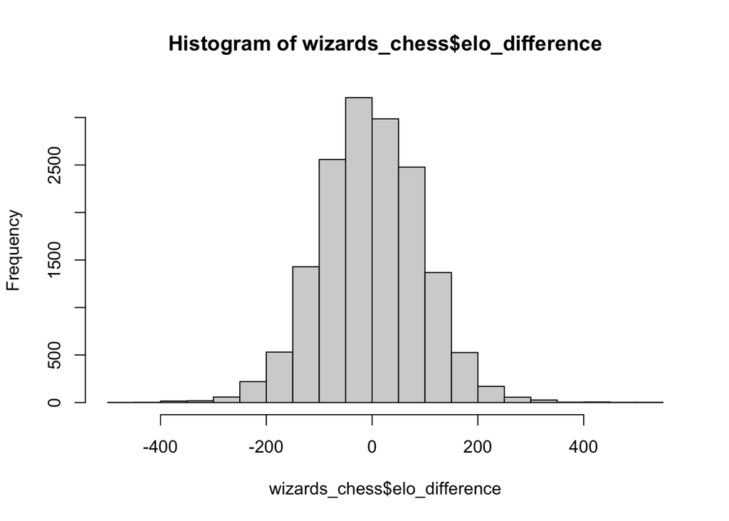

```r
hist(wizards_chess$elo_difference)
```

It looks like a normal distribution which is great. And the Elo rating difference between white and black players isn’t skewed and that there isn’t a large difference in skill level.

## Modelling Part 1 - Multinomial logistic regression

We use multinomial regression since we have three outcomes: white win, black win and draw

```r
# Splitting the data into the train and test datasets
# 70% for train and 30% for test

id = sample(1:nrow(wizards_chess), .3 * nrow(wizards_chess))
dataset.test <- wizards_chess[id,]
dataset.train <- wizards_chess[-id,]

# Create the multinomial model for the train dataset
model1 <- multinom(winner ~ adjusted_elo_difference + eco_cat + adjusted_white_elo + adjusted_black_elo, dataset.train)
```

Use the stepAIC function to choose a model by AIC in a stepwise algorithm. stepAIC is used for feature selection, essentially to simplify the model without impacting its performance.  
AIC quantifies the amount of information loss due to this simplification.  
AIC = Akaike Information Criteria.

```r
model1 <- stepAIC(model1, direction = "both") #MASS package
```

```
## Start:  AIC=21548.74
## winner ~ adjusted_elo_difference + eco_cat + adjusted_white_elo +
##     adjusted_black_elo
##
##
## Step:  AIC=21548.74
## winner ~ adjusted_elo_difference + eco_cat + adjusted_white_elo
##
##                           Df   AIC
## <none>                       21549
## - adjusted_white_elo       2 21554
## - eco_cat                 26 21619
## - adjusted_elo_difference  2 22171
```

```r
# stepAIC removed adjusted_black_elo but not adjusted_white_elo
# the final formula for multinomial regression is winner ~ adjusted_elo_difference + eco_cat + adjusted_white_elo
```

Interestingly adjusted black elo is removed but not adjusted white elo.

```r
# Predicting the values for train dataset
dataset.train$winner_predicted <- predict(model1, newdata = dataset.train, "class")

# Building classification table
tab <- table(dataset.train$winner, dataset.train$winner_predicted)
tab
```

```
##
##         black draw white
##   black    26 2008   145
##   draw     19 5088   479
##   white     7 2552   642
```

```r
# Calculating accuracy - sum of diagonal elements divided by total obs
round((sum(diag(tab))/sum(tab))*100,2)
```

```
## [1] 52.49
```

Accuracy is 52% for the train dataset.

```r
# Predicting the values for test dataset
dataset.test$winner_predicted <- predict(model1, newdata = dataset.test, "class")

# Building classification table
tab <- table(dataset.test$winner, dataset.test$winner_predicted)
tab
```

```
##
##         black draw white
##   black     7  873    70
##   draw      5 2135   226
##   white     5 1062   316
```

```r
# Calculating accuracy - sum of diagonal elements divided by total obs
round((sum(diag(tab))/sum(tab))*100,2)
```

```
## [1] 52.31
```

The accuracy of the test dataset is 52% which isn’t great because a draw happens 50% of the time so this is only slightly better than predicting a draw.